# Final Project:

# High-Margin Growth Strategy- Identifying Product Combinations That Drive Spend

## Introduction

To identify potential cross-selling opportunities, we analyzed the different types of product categories purchased by customers at REGORK. Our focus was on distinguishing between high-margin and high-volume products, with the aim of combining these categories strategically. By promoting complementary product categories together, we sought to uncover growth potential and opportunities to increase overall sales and profitability.

Based on this objective, we formulated two central research questions:

- Which high-margin product categories are most frequently purchased together with other categories, indicating strong cross-selling affinity?
- Which product bundles could REGORK test to increase average basket value and margin among target customers?

To answer these questions, we used the Complete Journey dataset, focusing primarily on the transactions, products, and demographics tables to derive meaningful insights into customer purchasing behavior.

By the end of this analysis, REGORK will gain a clearer understanding of the relationships between product categories and receive data-driven recommendations to support sales growth and margin improvement.

## Python Packages

| Package | Purpose |
| --- | --- |
| **Pandas** | Working with DataFrames (loading, cleaning, and transforming data) |
| **completejourney_py** | Provides access to real retail transaction data for analysis and EDA |
| **Matplotlib** | Creating visualizations (e.g., charts and plots) |
| **Counter** | Counting frequencies of elements (e.g., products, categories) |

### Import the dataset

```python
import pandas as pd
from completejourney_py import get_data
import matplotlib.pyplot as plt
```

```python
cj = get_data()
print("Available cj_data tables:", list(cj.keys()))
```

```
Available cj_data tables: ['campaign_descriptions', 'coupons', 'promotions', 'campaigns', 'demographics', 'transactions', 'coupon_redemptions', 'products']
```

```python
transactions = cj['transactions']
demographics = cj['demographics']
products = cj['products']
```

```python
print("transactions columns:", transactions.columns.tolist())
print("products columns:", products.columns.tolist())
print("households columns:", demographics.columns.tolist())
```

```
transactions columns: ['household_id', 'store_id', 'basket_id', 'product_id', 'quantity', 'sales_value', 'retail_disc', 'coupon_disc', 'coupon_match_disc', 'week', 'transaction_timestamp']
products columns: ['product_id', 'manufacturer_id', 'department', 'brand', 'product_category', 'product_type', 'package_size']
households columns: ['household_id', 'age', 'income', 'home_ownership', 'marital_status', 'household_size', 'household_comp', 'kids_count']
```

### Merge the datasets

```python
# Merge transactions + products
tx = transactions.merge(products, on="product_id", how="left")
# Merge with demographics
tx = tx.merge(demographics, on="household_id", how="left")
```

```python
tx["transaction_timestamp"] = pd.to_datetime(tx["transaction_timestamp"])
tx["date"] = tx["transaction_timestamp"].dt.date
```

### Initial Analysis

This initial analysis provides a general overview of which product categories are purchased most frequently and generate the highest sales. After this brief overview, we focus on high-margin and high-volume product categories to identify opportunities for combining them and leveraging cross-selling effects to increase sales.

### 1. Top 10 Categories by Revenue

```python
top_cats = (
    tx.groupby("product_category")["sales_value"].sum().sort_values(ascending=False).head(10))

top_cats
```

```
product_category
COUPON/MISC ITEMS         385971.85
SOFT DRINKS               182126.30
BEEF                      176614.54
FLUID MILK PRODUCTS       116360.68
CHEESE                    107011.61
FRZN MEAT/MEAT DINNERS     93023.74
BAG SNACKS                 84943.85
BAKED BREAD/BUNS/ROLLS     82429.70
BEERS/ALES                 82039.45
FROZEN PIZZA               81175.04
Name: sales_value, dtype: float64
```

Top revenue-generating categories such as soft drinks, beef, milk, and cheese act as core basket drivers, reflecting strong and consistent customer demand. High sales in frozen meals and pizza highlight a clear preference for convenient meal solutions, while snacks and baked bread frequently appear alongside these staples. These patterns indicate strong opportunities to pair high-margin items with these high-traffic essentials to drive incremental basket value.

### 2. Top 10 Products by Units Sold

```python
top_products = (tx.groupby("product_type")["quantity"].sum().sort_values(ascending=False).head(10))
top_products
```

```
product_type
GASOLINE-REG UNLEADED             151020580
FLUID MILK WHITE ONLY                 52443
YOGURT NOT MULTI-PACKS                38209
SOFT DRINKS 12/18&15PK CAN CAR        31759
SFT DRNK 2 LITER BTL CARB INCL        29753
CANDY BARS (SINGLES)(INCLUDING        26058
SHREDDED CHEESE                       20256
MAINSTREAM WHITE BREAD                19273
CONDENSED SOUP                        18196
BANANAS                               18036
Name: quantity, dtype: int64
```

### 3. Products bought together [Basket analysis]

```python
from collections import Counter

# Group categories per basket
basket_groups = tx.groupby("basket_id")["product_category"].apply(list)

pair_counter = Counter()

for cats in basket_groups:
    # remove None values
    cats = [c for c in cats if pd.notna(c)]

    # ensure uniques
    unique_cats = list(set(cats))

    # skip empty or single-item baskets
    if len(unique_cats) < 2:
        continue

    # count all pairs
    for i in range(len(unique_cats)):
        for j in range(i+1, len(unique_cats)):
            # no sorting needed, but if you want consistent ordering:
            pair = tuple(sorted([unique_cats[i], unique_cats[j]]))
            pair_counter[pair] += 1

# top 15 pairs
top_pairs = pair_counter.most_common(15)
top_pairs
```

```
[(('BAKED BREAD/BUNS/ROLLS', 'FLUID MILK PRODUCTS'), 17554),
 (('FLUID MILK PRODUCTS', 'SOFT DRINKS'), 14234),
 (('CHEESE', 'FLUID MILK PRODUCTS'), 14017),
 (('BAKED BREAD/BUNS/ROLLS', 'SOFT DRINKS'), 13703),
 (('BAKED BREAD/BUNS/ROLLS', 'CHEESE'), 13614),
 (('BAG SNACKS', 'SOFT DRINKS'), 11480),
 (('BAG SNACKS', 'BAKED BREAD/BUNS/ROLLS'), 11221),
 (('BAKED BREAD/BUNS/ROLLS', 'BEEF'), 10637),
 (('CHEESE', 'SOFT DRINKS'), 10501),
 (('BAG SNACKS', 'FLUID MILK PRODUCTS'), 10473),
 (('FLUID MILK PRODUCTS', 'TROPICAL FRUIT'), 10240),
 (('BEEF', 'FLUID MILK PRODUCTS'), 10103),
 (('EGGS', 'FLUID MILK PRODUCTS'), 9857),
 (('COLD CEREAL', 'FLUID MILK PRODUCTS'), 9534),
 (('BAG SNACKS', 'CHEESE'), 9423)]
```

The most frequent category pairs such as baked bread with fluid milk, cheese with soft drinks, and bag snacks with soft drinks highlight strong complementary purchasing behavior around staple and convenience items. These combinations suggest that customers naturally assemble simple meal and snack bundles during their trips. Such consistently co-purchased pairs provide clear opportunities to introduce targeted high-margin bundle promotions to lift basket value.

To further analyze the potential of high-margin product categories, the following main analysis examines which high-selling product categories, by sales value and quantity as identified in the initial analysis, are usually combined with them.

## Top High-Margin Categories (by Avg Unit Price)

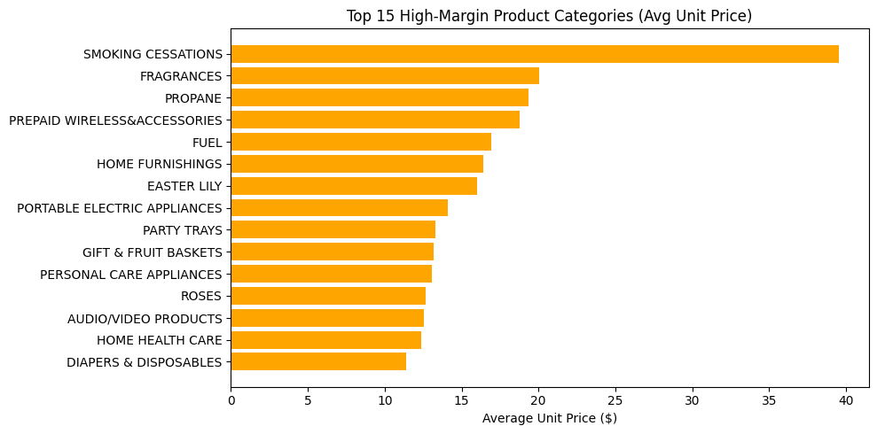

```python
df = transactions.merge(products, on='product_id', how='inner')

df['quantity'] = df['quantity'].replace(0, 1)
df['unit_price'] = df['sales_value'] / df['quantity']

cat_margin = (df.groupby('product_category')['unit_price'].mean().sort_values(ascending=False).head(15))

plt.figure(figsize=(10,5))
plt.barh(cat_margin.index[::-1], cat_margin.values[::-1], color='orange')
plt.title("Top 15 High-Margin Product Categories (Avg Unit Price)")
plt.xlabel("Average Unit Price ($)")
plt.tight_layout()
plt.show()
```

## High-Margin Category Share by Month

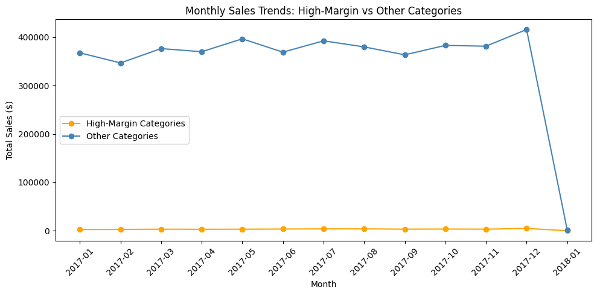

```python
df['month'] = df['transaction_timestamp'].dt.to_period('M')

monthly_sales = df.groupby(['month', 'product_category'])['sales_value'].sum().reset_index()

hm_monthly = monthly_sales[monthly_sales['product_category'].isin(high_margin_cats)]
other_monthly = monthly_sales[~monthly_sales['product_category'].isin(high_margin_cats)]

hm_monthly_grouped = hm_monthly.groupby('month')['sales_value'].sum()
other_monthly_grouped = other_monthly.groupby('month')['sales_value'].sum()

plt.figure(figsize=(10,5))
plt.plot(hm_monthly_grouped.index.astype(str), hm_monthly_grouped.values, marker='o', color='orange', label='High-Margin Categories')
plt.plot(other_monthly_grouped.index.astype(str), other_monthly_grouped.values, marker='o', color='steelblue', label='Other Categories')

plt.title("Monthly Sales Trends: High-Margin vs Other Categories")
plt.xlabel("Month")
plt.ylabel("Total Sales ($)")
plt.xticks(rotation=45)
plt.legend()
plt.tight_layout()
plt.show()
```

## Top 15 Co-purchased with high-margin categories

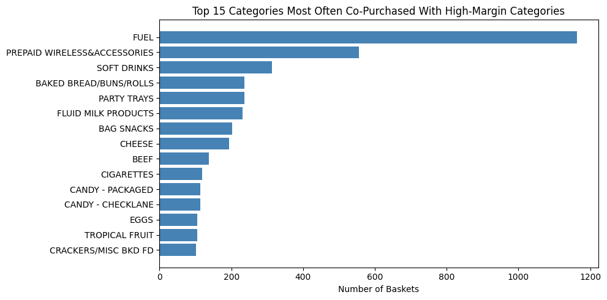

```python
hm_df = df[df['product_category'].isin(high_margin_cats)]

basket_ids = hm_df['basket_id'].unique()
co_df = df[df['basket_id'].isin(basket_ids)]

co_counts = (co_df.groupby('product_category')['basket_id'].nunique().sort_values(ascending=False).head(15))

plt.figure(figsize=(10,5))
plt.barh(co_counts.index[::-1], co_counts.values[::-1], color='steelblue')
plt.title("Top 15 Categories Most Often Co-Purchased With High-Margin Categories")
plt.xlabel("Number of Baskets")
plt.tight_layout()
plt.show()
```

Fuel and prepaid wireless products appear most frequently alongside high-margin categories, indicating that customers often combine essential utility purchases with discretionary, higher-value items. Everyday staples like soft drinks, baked bread, milk, and snacks also rank highly, showing strong natural affinity between routine grocery items and premium products. These consistent co-purchase patterns highlight clear opportunities to design targeted cross-sell bundles that link high-traffic essentials with high-margin categories to lift overall basket value.

## Top Products Within High-Margin Categories (by Sales)

[figure not shown]

```python
hm_products = df[df['product_category'].isin(high_margin_cats)]

top_products = (hm_products.groupby('product_id')['sales_value'].sum().sort_values(ascending=False).head(15).reset_index())
top_products = top_products.merge(products[['product_id','product_type']], on='product_id', how='left')

plt.figure(figsize=(10,5))
plt.barh(top_products['product_type'][::-1], top_products['sales_value'][::-1], color='orange')
plt.title("Top 15 Products Within High-Margin Categories (by Sales)")
plt.xlabel("Total Sales ($)")
plt.tight_layout()
plt.show()
```

Within high-margin categories, gasoline overwhelmingly leads total sales, indicating it is the primary revenue driver among premium-priced items despite being purchased for necessity rather than discretionary choice. Prepaid wireless cards also contribute meaningfully, reflecting steady demand for communication-related purchases. Most other high-margin products—such as deli trays, propane exchanges, and smoking cessation items—generate relatively modest but consistent sales, making them strong candidates for targeted cross-sell bundles to lift overall profitability.

## Basket Complexity: Categories per Basket

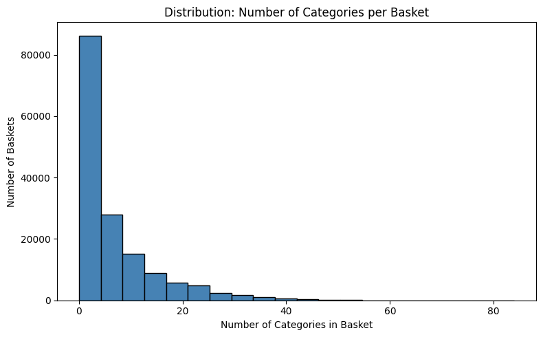

```python
basket_category_counts = df.groupby('basket_id')['product_category'].nunique()

plt.figure(figsize=(8,5))
plt.hist(basket_category_counts, bins=20, color='steelblue', edgecolor='black')
plt.title("Distribution: Number of Categories per Basket")
plt.xlabel("Number of Categories in Basket")
plt.ylabel("Number of Baskets")
plt.tight_layout()
plt.show()
```

Most baskets contain only a small number of product categories, with the majority falling between 1 and 10 categories, indicating that customers generally make focused, purpose-driven shopping trips. However, the long tail of larger baskets some containing 20+ categories shows that a meaningful share of shoppers engage in broad, multi-category purchases. This mix suggests that cross-sell opportunities exist both in routine small trips and in larger stock-up trips, making targeted bundling strategies broadly applicable.

## Conclusion and Final Recommendations

We aimed to identify product bundles within the Complete Journey dataset that represent customer purchasing behavior at REGORK and have the potential to increase sales and drive growth. Our analysis shows that while high-margin categories contribute relatively modest total sales compared to core grocery staples, they present a strong opportunity for profitable growth. Customers consistently pair these high-margin items such as prepaid wireless products, smoking cessation items, party trays with high-traffic essentials like fuel, soft drinks, milk, bread, and snacks. Additionally, basket composition patterns reveal that most shoppers make focused, low-category trips, but a significant number engage in larger multi-category purchases, creating multiple avenues for cross-sell strategies. The consistent co-occurrence between high-margin and essential categories indicates clear potential to leverage natural shopping behavior to increase both basket size and overall profitability. For a more detailed and customer-oriented approach, it would be helpful to analyze which customers purchase which essential product categories and how frequently they do so, in order to offer high-margin products specifically targeted to them. However, this goes beyond the scope of our current analysis and would require a separate, more in-depth analysis.

#### 1. Launch targeted cross-sell bundles pairing high-margin items with high-traffic essentials

Create promotional bundles such as:

Soft Drinks + High-Margin Wireless Accessories Bread/Milk + Smoking Cessation Products Snacks + High-Margin Gift or Personal Care Items These bundles align with natural co-purchase patterns and increase exposure to high-margin categories.

#### 2. Implement personalized digital offers for high-margin items

Use loyalty card data to identify customers who frequently purchase essential categories and offer exclusive high-margin add-on deals to lift profitability.

#### 3. Optimize in-store placement and signage for co-purchased categories

Place high-margin items near top-selling essentials or at key touchpoints such as: beverage/snack aisles bread/dairy sections checkout lanes (candy, cigarettes, wireless cards)

This increases visibility and encourages impulse buying aligned with co-purchase behavior.